# Tutorial Completo de Metanálise com ‘metafor’

2025-08-31

# Introdução

Este documento R Markdown é um tutorial completo do fluxo de trabalho para uma metanálise, utilizando o pacote `metafor`. Cada etapa é apresentada em um bloco de código executável (`chunk`), mostrando tanto o código-fonte quanto seus resultados, tornando-o ideal para aprendizado e prática.

# ETAPA 1: Preparação do Ambiente e Criação dos Dados

Primeiro, carregamos os pacotes necessários. Se você ainda não os instalou, rode `install.packages("metafor")` e `install.packages("tidyverse")` no seu Console do R.

```r
library(metafor)
library(tidyverse)
```

Em vez de carregar um arquivo externo, vamos criar um data frame de exemplo (`dat1`) para este tutorial. Ele simula os dados extraídos de 12 estudos que avaliaram um tratamento para redução de um score de ansiedade.

```r
dat1 <- data.frame(
  # Identificação do estudo
  study_id = c("Silva et al., 2020", "Chen et al., 2021", "Patel et al., 2019",
               "Jones et al., 2022", "Kim et al., 2020", "Garcia et al., 2023",
               "Smith et al., 2018", "Li et al., 2022", "Müller et al., 2021",
               "Chou et al., 2023", "Davis et al., 2019", "Abe et al., 2024"),
  # Dados do grupo de Tratamento
  mean_treat = c(15.2, 18.5, 12.1, 14.8, 19.0, 13.5, 16.1, 17.2, 11.8, 15.5, 12.9, 17.8),
  sd_treat = c(4.1, 5.2, 3.8, 4.5, 5.5, 3.9, 4.8, 4.9, 3.5, 4.2, 3.7, 5.0),
  n_treat = c(50, 65, 45, 70, 60, 80, 55, 75, 40, 68, 48, 72),
  # Dados do grupo Controle
  mean_control = c(18.9, 21.0, 15.5, 19.2, 22.5, 17.8, 20.3, 20.9, 16.1, 19.8, 16.5, 22.1),
  sd_control = c(4.5, 5.8, 4.0, 4.9, 6.0, 4.2, 5.1, 5.3, 3.9, 4.8, 4.1, 5.4),
  n_control = c(52, 68, 48, 72, 62, 85, 58, 78, 42, 70, 50, 75),
  # Variáveis moderadoras
  age_group = factor(c("Adultos", "Idosos", "Adultos", "Jovens", "Idosos", "Adultos",
                       "Adultos", "Jovens", "Adultos", "Idosos", "Jovens", "Idosos")),
  publication_year = c(2020, 2021, 2019, 2022, 2020, 2023, 2018, 2022, 2021, 2023, 2019, 2024)
)

# Vamos visualizar as primeiras linhas do nosso dataset para confirmar
head(dat1)
```

```
##              study_id mean_treat sd_treat n_treat mean_control sd_control
## 1  Silva et al., 2020       15.2      4.1      50         18.9        4.5
## 2   Chen et al., 2021       18.5      5.2      65         21.0        5.8
## 3  Patel et al., 2019       12.1      3.8      45         15.5        4.0
## 4  Jones et al., 2022       14.8      4.5      70         19.2        4.9
## 5    Kim et al., 2020       19.0      5.5      60         22.5        6.0
## 6 Garcia et al., 2023       13.5      3.9      80         17.8        4.2
##   n_control age_group publication_year
## 1        52   Adultos             2020
## 2        68    Idosos             2021
## 3        48   Adultos             2019
## 4        72    Jovens             2022
## 5        62    Idosos             2020
## 6        85   Adultos             2023
```

# ETAPA 2: Cálculo dos Tamanhos de Efeito (Effect Sizes)

Com os dados criados, usamos `escalc()` para calcular o tamanho do efeito (`yi`) e sua variância (`vi`). Neste exemplo, usaremos a Diferença de Médias Padronizada (SMD), que por padrão é o **g de Hedges**.

```r
dat1 <- escalc(measure = "SMD",
               m1i = mean_treat, sd1i = sd_treat, n1i = n_treat,
               m2i = mean_control, sd2i = sd_control, n2i = n_control,
               data = dat1)

# Visualizar o dataset novamente, agora com as colunas yi e vi
head(dat1)
```

```
##
##              study_id mean_treat sd_treat n_treat mean_control sd_control
## 1  Silva et al., 2020       15.2      4.1      50         18.9        4.5
## 2   Chen et al., 2021       18.5      5.2      65         21.0        5.8
## 3  Patel et al., 2019       12.1      3.8      45         15.5        4.0
## 4  Jones et al., 2022       14.8      4.5      70         19.2        4.9
## 5    Kim et al., 2020       19.0      5.5      60         22.5        6.0
## 6 Garcia et al., 2023       13.5      3.9      80         17.8        4.2
##   n_control age_group publication_year      yi     vi
## 1        52   Adultos             2020 -0.8523 0.0428
## 2        68    Idosos             2021 -0.4507 0.0309
## 3        48   Adultos             2019 -0.8636 0.0471
## 4        72    Jovens             2022 -0.9297 0.0312
## 5        62    Idosos             2020 -0.6039 0.0343
## 6        85   Adultos             2023 -1.0549 0.0276
```

# ETAPA 3: Execução do Modelo Principal de Metanálise

Agora, combinamos os tamanhos de efeito em um modelo de efeitos aleatórios com `rma()`.

```r
overall_result <- rma(yi, vi, data = dat1)

# Exibimos o resumo do modelo, mostrando o efeito geral combinado,
# o intervalo de confiança e as estatísticas de heterogeneidade.
print(overall_result)
```

```
##
## Random-Effects Model (k = 12; tau^2 estimator: REML)
##
## tau^2 (estimated amount of total heterogeneity): 0.0024 (SE = 0.0158)
## tau (square root of estimated tau^2 value):      0.0488
## I^2 (total heterogeneity / total variability):   6.30%
## H^2 (total variability / sampling variability):  1.07
##
## Test for Heterogeneity:
## Q(df = 11) = 11.1314, p-val = 0.4323
##
## Model Results:
##
## estimate      se      zval    pval    ci.lb    ci.ub
##  -0.8331  0.0560  -14.8674  <.0001  -0.9429  -0.7232  ***
##
## ---
## Signif. codes:  0 '***' 0.001 '**' 0.01 '*' 0.05 '.' 0.1 ' ' 1
```

# ETAPA 4: Visualização e Diagnóstico

## Forest Plot

O *Forest Plot* é a principal forma de visualização em metanálises.

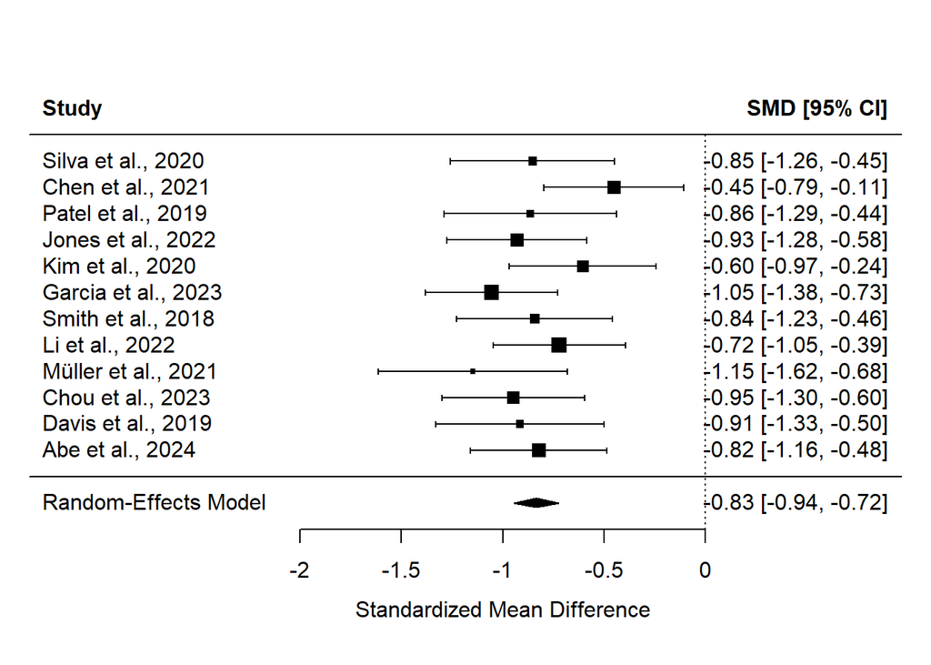

```r
forest(overall_result, slab = dat1$study_id, header = TRUE)
```

## Diagnóstico de Influência

Verificamos se algum estudo está influenciando desproporcionalmente o resultado. O R marca com um asterisco (`*`) os estudos que merecem atenção.

```r
influence(overall_result)
```

```
##
##    rstudent  dffits cook.d  cov.r tau2.del  QE.del    hat  weight    dfbs inf
## 1   -0.0883 -0.0143 0.0002 1.1572   0.0051 11.1216 0.0695  6.9508 -0.0142
## 2    2.2849  0.7327 0.4984 1.0324   0.0000  5.9105 0.0945  9.4476  0.7304   *
## 3   -0.1361 -0.0268 0.0008 1.1419   0.0049 11.1095 0.0635  6.3501 -0.0266
## 4   -0.5324 -0.1612 0.0278 1.1746   0.0048 10.7971 0.0935  9.3452 -0.1616
## 5    1.2758  0.3840 0.1415 1.0488   0.0009  9.4644 0.0856  8.5623  0.3841
## 6   -1.4151 -0.5015 0.2315 1.0452   0.0000  9.1290 0.1046 10.4603 -0.4978
## 7   -0.0395 -0.0003 0.0000 1.1750   0.0054 11.1290 0.0767  7.6697 -0.0003
## 8    0.6598  0.2304 0.0572 1.1859   0.0047 10.6303 0.1039 10.3861  0.2318
## 9   -1.3485 -0.3199 0.0997 1.0098   0.0008  9.2850 0.0530  5.3014 -0.3227
## 10  -0.6243 -0.1895 0.0379 1.1568   0.0043 10.6822 0.0907  9.0688 -0.1897
## 11  -0.3723 -0.0923 0.0089 1.1362   0.0046 10.9751 0.0661  6.6139 -0.0916
## 12   0.0695  0.0363 0.0015 1.2252   0.0062 11.1267 0.0984  9.8437  0.0366
```

# ETAPA 5: Análise de Moderadores

Investigamos a heterogeneidade encontrada usando as variáveis moderadoras que criamos.

## A. Moderador Categórico

Testamos se a **faixa etária** (`age_group`) explica a variação nos resultados.

Primeiro, o teste geral (Q-entre-grupos):

```r
mod_categorico_Q <- rma(yi, vi, mods = ~ factor(age_group), data = dat1)
print(mod_categorico_Q)
```

```
##
## Mixed-Effects Model (k = 12; tau^2 estimator: REML)
##
## tau^2 (estimated amount of residual heterogeneity):     0 (SE = 0.0166)
## tau (square root of estimated tau^2 value):             0
## I^2 (residual heterogeneity / unaccounted variability): 0.00%
## H^2 (unaccounted variability / sampling variability):   1.00
## R^2 (amount of heterogeneity accounted for):            100.00%
##
## Test for Residual Heterogeneity:
## QE(df = 9) = 7.3338, p-val = 0.6024
##
## Test of Moderators (coefficients 2:3):
## QM(df = 2) = 3.7975, p-val = 0.1498
##
## Model Results:
##
##                          estimate      se      zval    pval    ci.lb    ci.ub
## intrcpt                   -0.9528  0.0897  -10.6240  <.0001  -1.1286  -0.7770
## factor(age_group)Idosos    0.2457  0.1263    1.9456  0.0517  -0.0018   0.4933
## factor(age_group)Jovens    0.1103  0.1383    0.7972  0.4253  -0.1609   0.3814
##
## intrcpt                  ***
## factor(age_group)Idosos    .
## factor(age_group)Jovens
##
## ---
## Signif. codes:  0 '***' 0.001 '**' 0.01 '*' 0.05 '.' 0.1 ' ' 1
```

Em seguida, o modelo sem o intercepto (`- 1`) para ver o efeito médio de cada grupo.

```r
mod_categorico_grupos <- rma(yi, vi, mods = ~ factor(age_group) - 1, data = dat1)
print(mod_categorico_grupos)
```

```
##
## Mixed-Effects Model (k = 12; tau^2 estimator: REML)
##
## tau^2 (estimated amount of residual heterogeneity):     0 (SE = 0.0166)
## tau (square root of estimated tau^2 value):             0
## I^2 (residual heterogeneity / unaccounted variability): 0.00%
## H^2 (unaccounted variability / sampling variability):   1.00
##
## Test for Residual Heterogeneity:
## QE(df = 9) = 7.3338, p-val = 0.6024
##
## Test of Moderators (coefficients 1:3):
## QM(df = 3) = 240.0679, p-val < .0001
##
## Model Results:
##
##                           estimate      se      zval    pval    ci.lb    ci.ub
## factor(age_group)Adultos   -0.9528  0.0897  -10.6240  <.0001  -1.1286  -0.7770
## factor(age_group)Idosos    -0.7071  0.0889   -7.9518  <.0001  -0.8814  -0.5328
## factor(age_group)Jovens    -0.8425  0.1053   -7.9979  <.0001  -1.0490  -0.6361
##
## factor(age_group)Adultos  ***
## factor(age_group)Idosos   ***
## factor(age_group)Jovens   ***
##
## ---
## Signif. codes:  0 '***' 0.001 '**' 0.01 '*' 0.05 '.' 0.1 ' ' 1
```

## B. Moderador Contínuo (Metarregressão)

Testamos se o **ano de publicação** (`publication_year`) tem uma relação linear com o tamanho do efeito.

```r
mod_continuo <- rma(yi, vi, mods = ~ publication_year, data = dat1)
print(mod_continuo)
```

```
##
## Mixed-Effects Model (k = 12; tau^2 estimator: REML)
##
## tau^2 (estimated amount of residual heterogeneity):     0.0038 (SE = 0.0173)
## tau (square root of estimated tau^2 value):             0.0613
## I^2 (residual heterogeneity / unaccounted variability): 9.60%
## H^2 (unaccounted variability / sampling variability):   1.11
## R^2 (amount of heterogeneity accounted for):            0.00%
##
## Test for Residual Heterogeneity:
## QE(df = 10) = 10.6927, p-val = 0.3820
##
## Test of Moderators (coefficient 2):
## QM(df = 1) = 0.3750, p-val = 0.5403
##
## Model Results:
##
##                   estimate       se     zval    pval     ci.lb     ci.ub
## intrcpt            38.8313  64.7679   0.5995  0.5488  -88.1115  165.7740
## publication_year   -0.0196   0.0320  -0.6124  0.5403   -0.0824    0.0432
##
## ---
## Signif. codes:  0 '***' 0.001 '**' 0.01 '*' 0.05 '.' 0.1 ' ' 1
```